# FLARe case-control analysis

Tom McGregor

30 April, 2020

# Setup

## Steps

- Clear workspace
- Load packages
- Set seed
- Save date
- Import objects created from cleaning script
- Create functions
- Set parameterized objects
- Comparison being made: **anx_cont**
- Create folders

## Invited v. consented comparisons

### Age

d = 0.07; t(5909.91) = 2.76, p = 0.006.

### Gender

OR = 1.67; 95% CI = 1.5, 1.86, p < 0

## Exclusion drop

Exclusions for task avoidance: restarts/volume/headphones/instructions.

Number of participants before exclusion drop: **2363**.

| Exclude | GAD-7 M (SE) |
| --- | --- |
| no (n = 1625) | 5.43 (0.13) |
| yes (n = 738) | 6.31 (0.2) |

GAD-7 difference between included and excluded participants: **d = -0.17; t(1319.39) = -3.69, p = 0.**

Dropping exclusions? **TRUE**.

Number of participants after drop (if applicable): **1625**.

## Task avoiders only

*Exclusion drop must equal FALSE*

Task avoidance: restarts/volume/headphones/instructions.

Number of participants before non-avoiders dropped: **1625**.

Dropping non-avoiders? **FALSE**.

Number of participants after drop (if applicable): **1625**.

## Incomplete cases check

Number of participants incomplete cases drop: **1625**.

Dropping incomplete cases? **TRUE**.

Number of participants after drop (if applicable): **1608**.

## Twin check

Number of participants pre twin drop: **1608**.

Dropping twins? **FALSE**.

Number of participants after drop (if applicable): **1608**.

## Participant breakdown

Number of participants emailed: **5914**

Number of participants consented: **2987**

Number of participants who passed screening: **2925**

Number of participants who completed the study: **2363**

Number of participants who weren’t excluded: **1625**

Number of participants without missing data: **1608**

# Phenotypic check

## Group numbers

Number of participants in each group.

| group | n |
| --- | --- |
| case | 473 |
| control | 673 |
| missing | 462 |

Wide and long dataframes are created from cases and controls.

Participants who are missing for the grouping variable are removed.

## Sample table

Sample table

|  | Anxious (N = 473) | Non-anxious (N = 673) |
| --- | --- | --- |
| Sex (%) |  |  |
| Females | 390 (0.82) | 413 (0.61) |
| Males | 83 (0.18) | 260 (0.39) |
| Group means (SE) |  |  |
| Age | 23.58 (0.04) | 23.7 (0.03) |
| GAD-7 | 10.77 (0.24) | 1.61 (0.05) |
| Number of participants meeting criteria for one or both grouping conditions |  |  |
| Self-reported lifetime diagnosis | 174 | 0 |
| GAD-7 diagnosis | 167 | 0 |
| Self-reported lifetime diagnosis & GAD-7 diagnosis | 132 | 0 |

## Anxiety breakdown

Breakdown of self-reported, clinician-provided, diagnoses of anxiety disorders

|  | N |
| --- | --- |
| Generalised anxiety | 152 |
| Generalised anxiety & panic attacks | 57 |
| Generalised anxiety & social phobia | 31 |
| Panic attacks | 22 |
| Social phobia | 11 |
| Social phobia & panic attacks | 3 |
| Three or more diagnoses | 30 |

## Twin breakdown

Twin breakdown

Individuals, pairs and %MZ broken down across groups

|  | Individual twins | Twin pairs | %MZ |
| --- | --- | --- | --- |
| Concordant |  |  |  |
| Anxious | 106 | 53 | 64% |
| Non-anxious | 174 | 87 | 48% |
| Discordant |  |  |  |
| Cross-group | 114 | 57 | 37% |
| Singletons |  |  |  |
| Anxious | 310 | — | 40% |
| Non-anxious | 442 | — | 38% |
| Total | 1146 | 197 | 43% |

## Age

**Case v control comparison**

d = -0.15; t(998.34) = -2.46, p = 0.014.

## Gender

**Case v control comparison**

OR = 2.96; 95% CI = 2.21, 3.98, p < 0

## GAD & PHQ

### Correlations

Correlation between GAD and PHQ: 0.79, p = 0

| Measure | GAD | PHQ |
| --- | --- | --- |
| Acquisition_CS+ | -0.06 | -0.05 |
| Acquisition_CS- | 0.15 | 0.12 |
| Acquisition_Discrimination | -0.12 | -0.10 |
| Extinction_CS+ | 0.17 | 0.12 |
| Extinction_CS- | 0.13 | 0.11 |
| Extinction_Discrimination | 0.08 | 0.03 |

### T-tests

**GAD-7: case v control**

d = 2.58; t(519.13) = 36.96, p = 0.

**PHQ: case v control**

d = 1.9; t(548.47) = 27.59, p = 0.

# Expectancies

## Expectancy summary

|  | phase | stimulus | measure | case | control |
| --- | --- | --- | --- | --- | --- |
| 1 | Acquisition | CS+ | n | 473 | 673 |
| 2 | Acquisition | CS+ | missing | 0 | 0 |
| 3 | Acquisition | CS+ | min | 1 | 1.46 |
| 4 | Acquisition | CS+ | max | 9 | 9 |
| 5 | Acquisition | CS+ | mean | 6.95 | 7.15 |
| 6 | Acquisition | CS+ | median | 7.42 | 7.58 |
| 7 | Acquisition | CS+ | sd | 1.53 | 1.32 |
| 8 | Acquisition | CS+ | se | 0.07 | 0.05 |
| 9 | Acquisition | CS+ | lower_ci | 6.81 | 7.05 |
| 10 | Acquisition | CS+ | upper_ci | 7.08 | 7.25 |

[output cut: 62 more lines]

## Interaction plot

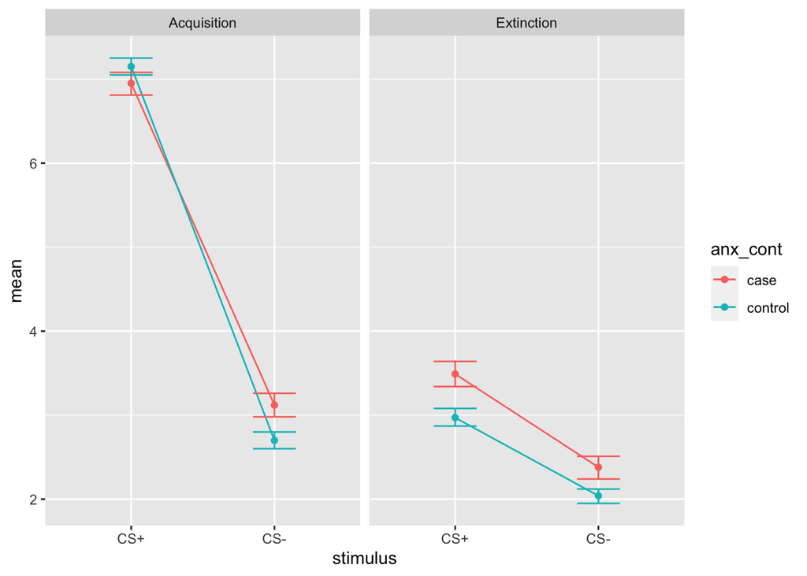

## Distributions 1: Scatterplots with boxplot overlays

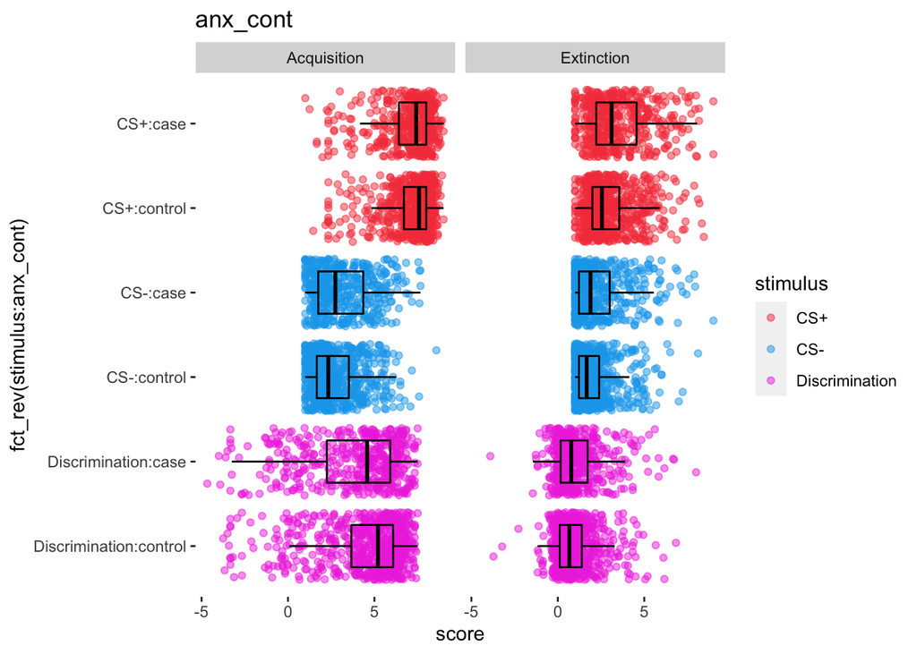

## Distributions 2: Density plots for each stimulus per condition

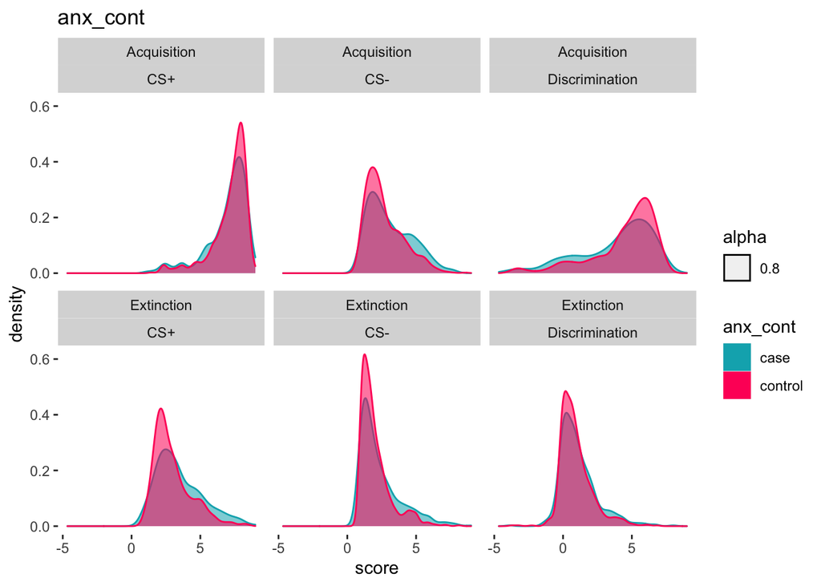

# Fear conditioning analyses

## Means

### ANOVAs

|  | phase | term | df | sumsq | meansq | statistic | p.value |
| --- | --- | --- | --- | --- | --- | --- | --- |
| 1 | Acquisition | get(group_comparison_char) | 1 | 6.42 | 6.42 | 3.134 | 0.077 |
| 2 | Acquisition | stimulus | 1 | 10061.187 | 10061.187 | 4910.528 | 0 |
| 3 | Acquisition | get(group_comparison_char):stimulus | 1 | 53.398 | 53.398 | 26.062 | 0 |
| 4 | Acquisition | Residuals | 2288 | 4687.886 | 2.049 |  |  |
| 5 | Extinction | get(group_comparison_char) | 1 | 101.71 | 101.71 | 51.342 | 0 |
| 6 | Extinction | stimulus | 1 | 581.903 | 581.903 | 293.74 | 0 |
| 7 | Extinction | get(group_comparison_char):stimulus | 1 | 4.452 | 4.452 | 2.247 | 0.134 |
| 8 | Extinction | Residuals | 2288 | 4532.565 | 1.981 |  |  |

### Follow-up tests

|  | phase | term | comparison | estimate | conf.low | conf.high | adj.p.value |
| --- | --- | --- | --- | --- | --- | --- | --- |
| 1 | Acquisition | get(group_comparison_char) | control-case | -0.108 | -0.227 | 0.012 | 0.077 |
| 2 | Acquisition | stimulus | CS--CS+ | -4.19 | -4.308 | -4.073 | 0 |
| 3 | Acquisition | get(group_comparison_char):stimulus | control:CS+-case:CS+ | 0.203 | -0.018 | 0.423 | 0.086 |
| 4 | Acquisition | get(group_comparison_char):stimulus | case:CS--case:CS+ | -3.826 | -4.065 | -3.587 | 0 |
| 5 | Acquisition | get(group_comparison_char):stimulus | control:CS--case:CS+ | -4.244 | -4.465 | -4.023 | 0 |
| 6 | Acquisition | get(group_comparison_char):stimulus | case:CS--control:CS+ | -4.029 | -4.25 | -3.808 | 0 |
| 7 | Acquisition | get(group_comparison_char):stimulus | control:CS--control:CS+ | -4.446 | -4.647 | -4.246 | 0 |
| 8 | Acquisition | get(group_comparison_char):stimulus | control:CS--case:CS- | -0.418 | -0.638 | -0.197 | 0 |
| 9 | Extinction | get(group_comparison_char) | control-case | -0.428 | -0.545 | -0.311 | 0 |
| 10 | Extinction | stimulus | CS--CS+ | -1.008 | -1.123 | -0.892 | 0 |

[output cut: 6 more lines]

### Intercepts

```
## [[1]]
##                                       Df Sum Sq Mean Sq   F value   Pr(>F)
## (Intercept)                            1  56610   56610 27629.654  < 2e-16
## get(group_comparison_char)             1      6       6     3.134   0.0768
## stimulus                               1  10061   10061  4910.528  < 2e-16
## get(group_comparison_char):stimulus    1     53      53    26.062 3.58e-07
## Residuals                           2288   4688       2
##
## (Intercept)                         ***
## get(group_comparison_char)          .
## stimulus                            ***
## get(group_comparison_char):stimulus ***
## Residuals
## ---
## Signif. codes:  0 '***' 0.001 '**' 0.01 '*' 0.05 '.' 0.1 ' ' 1
##
## [[2]]
##                                       Df Sum Sq Mean Sq  F value   Pr(>F)
## (Intercept)                            1  16480   16480 8318.838  < 2e-16
## get(group_comparison_char)             1    102     102   51.342 1.04e-12
## stimulus                               1    582     582  293.740  < 2e-16
## get(group_comparison_char):stimulus    1      4       4    2.247    0.134
## Residuals                           2288   4533       2
##
## (Intercept)                         ***
## get(group_comparison_char)          ***
## stimulus                            ***
## get(group_comparison_char):stimulus
## Residuals
## ---
## Signif. codes:  0 '***' 0.001 '**' 0.01 '*' 0.05 '.' 0.1 ' ' 1
```

## Discriminations

### ANOVAs

|  | phase | term | df | sumsq | meansq | statistic | p.value |
| --- | --- | --- | --- | --- | --- | --- | --- |
| 1 | Acquisition | get(group_comparison_char) | 1 | 106.795 | 106.795 | 17.204 | 0 |
| 2 | Acquisition | Residuals | 1144 | 7101.357 | 6.207 |  |  |
| 3 | Extinction | get(group_comparison_char) | 1 | 8.904 | 8.904 | 5.56 | 0.019 |
| 4 | Extinction | Residuals | 1144 | 1831.882 | 1.601 |  |  |

### Follow-up tests

|  | phase | term | comparison | estimate | conf.low | conf.high | adj.p.value |
| --- | --- | --- | --- | --- | --- | --- | --- |
| 1 | Acquisition | get(group_comparison_char) | control-case | 0.62 | 0.327 | 0.913 | 0 |
| 2 | Extinction | get(group_comparison_char) | control-case | -0.179 | -0.328 | -0.03 | 0.019 |

### Intercepts

```
## [[1]]
##                              Df Sum Sq Mean Sq F value   Pr(>F)
## (Intercept)                   1  20122   20122  3241.6  < 2e-16 ***
## get(group_comparison_char)    1    107     107    17.2 3.61e-05 ***
## Residuals                  1144   7101       6
## ---
## Signif. codes:  0 '***' 0.001 '**' 0.01 '*' 0.05 '.' 0.1 ' ' 1
##
## [[2]]
##                              Df Sum Sq Mean Sq F value Pr(>F)
## (Intercept)                   1 1163.8  1163.8  726.79 <2e-16 ***
## get(group_comparison_char)    1    8.9     8.9    5.56 0.0185 *
## Residuals                  1144 1831.9     1.6
## ---
## Signif. codes:  0 '***' 0.001 '**' 0.01 '*' 0.05 '.' 0.1 ' ' 1
```

## Expectancy means table

|  | Phase | Stimulus | Case (N = 473) | Control (N = 673) | HSD (95% CIs) | Cohen's d (95% CIs) | Adjusted p-value |
| --- | --- | --- | --- | --- | --- | --- | --- |
| 1 | Acquisition | CS+ | 6.95 (0.07) | 7.15 (0.05) | -0.2 (-0.42, 0.02) | -0.14 (-0.26, -0.03) | 0.086 |
| 2 | Acquisition | CS- | 3.12 (0.07) | 2.7 (0.05) | 0.42 (0.2, 0.64) | 0.29 (0.17, 0.4) | &lt; 0.001 |
| 3 | Acquisition | Discrimination | 3.83 (0.12) | 4.45 (0.09) | -0.62 (-0.91, -0.33) | -0.25 (-0.37, -0.13) | &lt; 0.001 |
| 4 | Extinction | CS+ | 3.49 (0.08) | 2.97 (0.05) | 0.52 (0.3, 0.74) | 0.34 (0.22, 0.46) | &lt; 0.001 |
| 5 | Extinction | CS- | 2.38 (0.07) | 2.04 (0.04) | 0.34 (0.12, 0.56) | 0.26 (0.14, 0.38) | &lt; 0.001 |
| 6 | Extinction | Discrimination | 1.11 (0.06) | 0.93 (0.05) | 0.18 (0.03, 0.33) | 0.14 (0.02, 0.26) | 0.019 |

## Extra

```r
df.long %>%
  filter(phase == "Extinction", stimulus != "Discrimination") %>%
  cohen.d(score ~ get(group_comparison_char), .)
```

```
##
## Cohen's d
##
## d estimate: 0.2861867 (small)
## 95 percent confidence interval:
##     lower     upper
## 0.2025760 0.3697973
```

# Plot

## Barplots

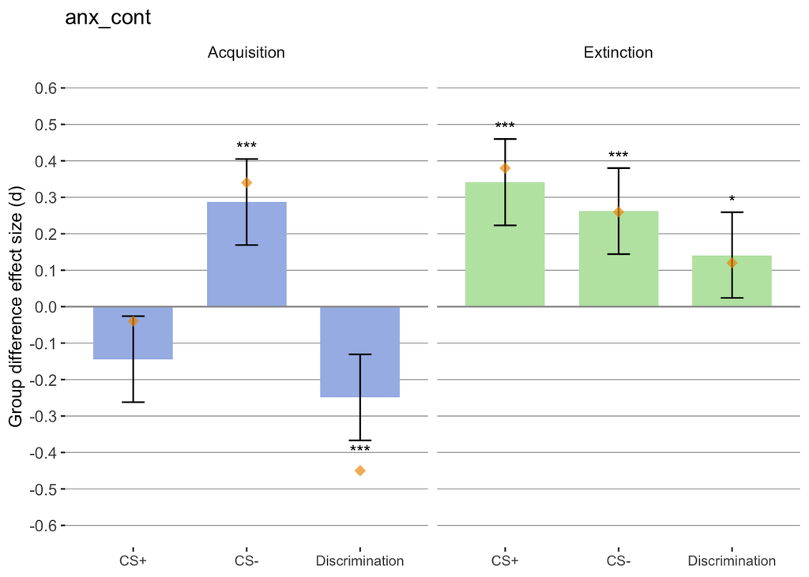

## Elephant plots

### Whole elephant

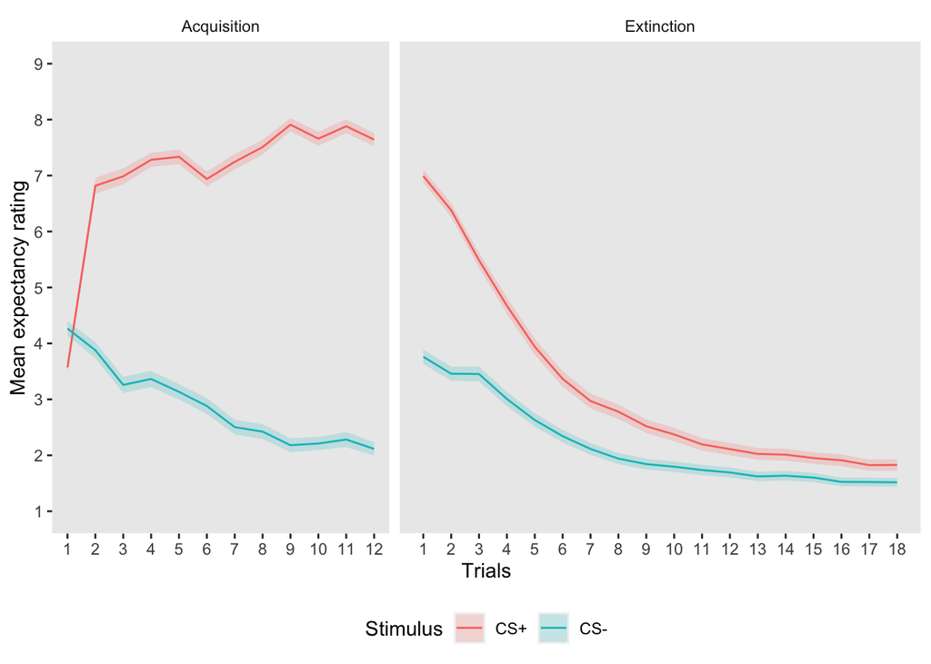

### Grouped elephants

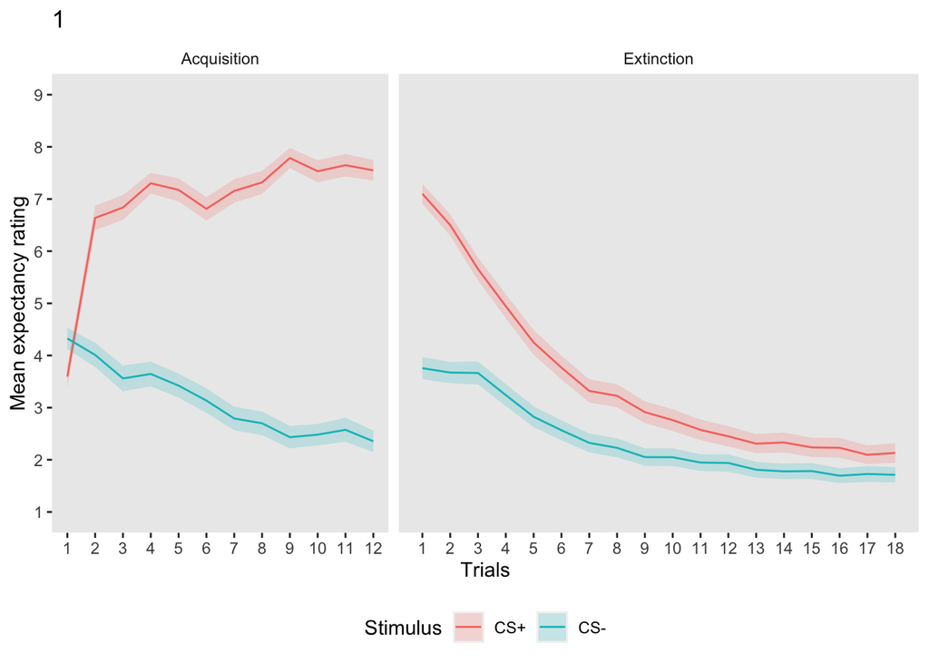

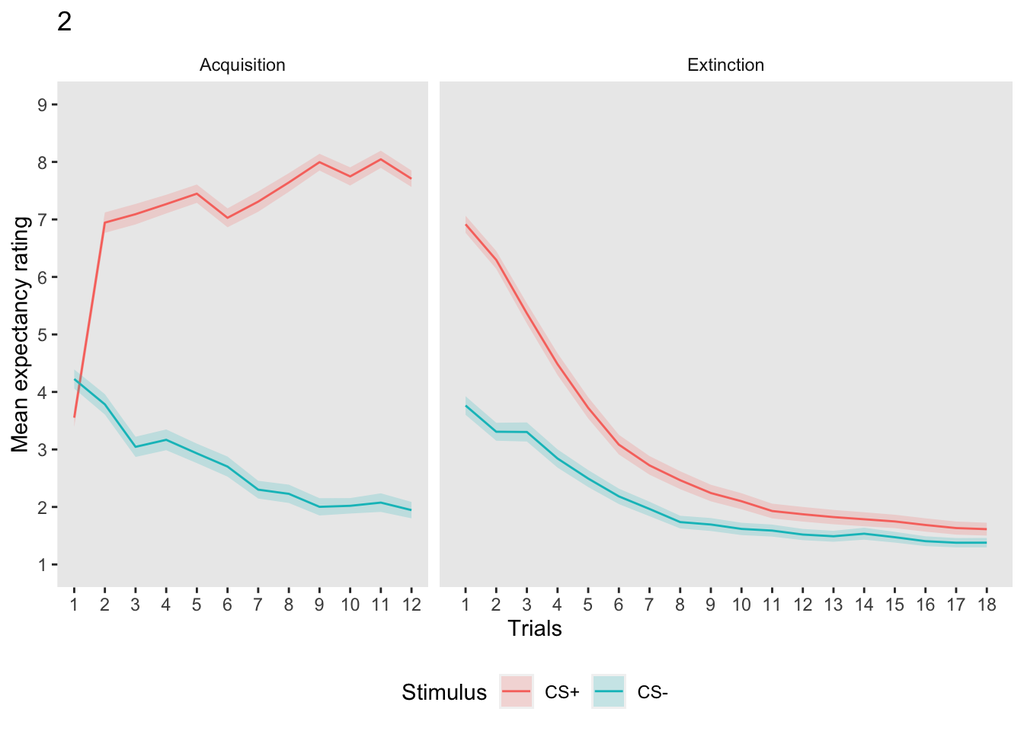